# National Cosmetology Written Practical 시험 CIB

발효일: 2022-07-01 개정 날짜: 2026-01-01

## CANDIDATE INFORMATION BULLETIN (CIB)

**시험 내용 및 중요 지침**

시험을 치르기 전에 공식 시험 제공 기관의 웹 사이트 또는 www.nictesting.org를 방문하여 최신 요강을 확인하십시오.*

National Cosmetology Written Practical 시험은 면허 교부 시험으로서 National-Interstate Council of State Boards of Cosmetology(NIC)에서 개발한 것입니다.

본 요강에는 National Cosmetology Written Practical 실습 시험 내용과 참조 문헌에 관한 중요 정보가 있습니다.

본 시험은 120 분 동안 치러야 합니다.

*모든 정보를 주의 깊게 검토하십시오.*

NIC National Written Practical 시험마다 여러 개의 파트로 구성된 응시자 정보 요강(CIB)이 있습니다:

- **중요 지침 및 시험 내용 범위 섹션** – 이 목록은 Written Practical 시험을 치르는 데 관련된 정보와 가이드라인, 시험에서 다루는 내용의 범위를 설명하는 정보를 제공합니다.
- **참조 문헌** - 시험마다 이론, 실기, 필기 실습 및 추가 섹션에 똑같은 참조 문헌이 사용될 예정입니다.

*본 NIC 시험과 관련된 응시자 정보 요강의 모든 부분을 신중히 검토하십시오!*

## 중요 지침

### 일반 사항

- 허락 없이 시험장을 떠나지 마십시오. 화장실을 가거나 시험을 완료한 경우를 비롯하여 어떤 이유에서든 시험장을 떠나려면 허락을 받아야 합니다. *시험장에 재입장하려면 사진 ID가 필요합니다.*
- 모든 시험은 시험 환경에서 시행됩니다.

### 시행 표준화

NIC National 시험의 표준화로 인해, 시험 감독관과 시험관은 다음 기준을 준수해야 합니다:

- 구두 지시를 제외하면 시험 감독관과 시험 시행 담당자는 응시자와 대화할 수 없습니다.
- 응시자에게 응급 상황이 발생하는 경우 손을 들어 시험 감독관에게 알려야 합니다.

### 금지 물품

- 다음은 시험이 시행되는 동안 시험장에서 금지되는 자료 및 행동의 예입니다:
  - 휴대폰, 손목시계(모든 종류), 호출기, 태블릿, 컴퓨터, 프로젝터, 카메라 또는 기타 전자 또는 녹화 장치, 인쇄물 또는 수기 노트의 지참.
  - 지갑, 가방, 코트, 모자 그리고 시험을 완료하는 데 직접 필요하지 않은 기타 개인 물품은 허용되지 않습니다.
- 다른 응시자나 시험관에게 대화 시도.
- 시험 진행을 방해하는 행동. 상기 언급된 항목이나 행동은 포괄적인 목록이 아닙니다.

이러한 조건을 준수하지 않거나 부정행위를 하려는 의도로 의심되는 행동을 보여주는 경우, 즉각적으로 시험에서 퇴실 조치를 당하게 되며 응시자의 행동은 해당 기관에 통보됩니다.

## COSMETOLOGY WRITTEN PRACTICAL 시험 내용 개요

### 부문 상세정보

다음은 NIC National Cosmetology Written Practical Examination 시험에서 다루는 응시 범위에 대한 개요를 제공합니다. 퍼센트는 각 부문의 문항 비율을 나타냅니다. 시험은 75 개 문항으로 구성되며, 이 중 65 개 문항에 가중치가 적용되어 응시자의 최종 점수에 반영됩니다.

참조일: January 01, 2026

1. 과학적 개념(20%) (20%)
   1. 감염관리및안전방침
      1. 감염 통제 원칙의 목적 및/또는 효과를 인식합니다.
         1. 감염 관리 프로세스: 교차오염 발생 시 인식
         2. 감염 관리 프로세스: 교차 오염 방지
         3. 감염 관리 프로세스: 일회용 도구와 다회용 도구의 용도 구분
      2. 혈액 접촉 절차를 적용합니다.
   2. 화장품에 사용되는 제품의 기본 화학
      1. 제품 및 성분의 목적과 효과를 인식합니다
      2. 화학 물질과의 물리적 상호 작용을 인식합니다.
      3. 화학 반응(과다 노출, 화학적 화상 등)을 이해합니다.
2. 헤어 케어 및 서비스(45%) (45%)
   1. 헤어 케어 서비스에 관한 고객 상담, 분석, 문서화 작업
      1. 고객의 모발 및 두피 상태를 헤아립니다(즉, 평가합니다).
      2. 서비스를 삼가야 하는 상태(금기 사항 등)를 인식합니다.
      3. 서비스 또는 제품을 결정합니다
      4. 사전 검사(알러지 성향 및 가닥 검사 등)의 용도를 인식하고 결과를 해석합니다.
      5. 고객 기록(서비스 이력, 고객 카드, 의료 이력 등)을 구축/유지합니다.
   2. 헤어 케어 서비스에 사용되는 도구
      1. 헤어 서비스에 사용되는 도구의 기능, 목적, 감염 관리 방법을 식별합니다.
         1. 장비(의자, 작업대 등)
         2. 기구(면도기, 가위, 빗/브러시 등)
         3. 용품 및 재료(수건, 드레이프, 목 스트립 등)
         4. 전기 도구(고데기, 드라이기, 이발기 등)
         5. 적절한 소독 절차
      2. 도구(장비, 도구, 용품, 인체 공학 등)의 안전한 사용을 위한 방침을 인식합니다.
   3. 헤어 케어
      1. 샴푸와 컨디셔닝의 원리와 절차에 관한 지식을 적용합니다.
      2. 두피 트리트먼트 및 두피 마사지의 원리와 절차에 관한 지식을 적용합니다.
      3. 드레이핑에 관한 지식(화학 물질, 샴푸, 컷등)을 적용합니다.
   4. 헤어 디자인
      1. 모발 컷 및 셰이핑의 원리, 절차, 안전성에 관한 지식을 적용합니다
      2. 헤어 스타일링의 원리, 절차, 안전성에 관한 지식을 적용합니다.
         1. 웻 스타일링
         2. 열 스타일링
         3. 자연스러운 헤어 스타일링(브레이드 등)
      3. 모발 강화의 원리, 절차, 안전성에 관한 지식을 적용합니다.
      4. 균형과 디자인의 원칙(얼굴 모양, 신체 구조 등)을 적용합니다.
   5. 케미컬 서비스
      1. 다음에 대한 원칙, 절차, 안전성에 관한 지식을 적용합니다.
         1. 헤어 컬러링(보정색 포함)
         2. 모발 탈색
         3. 포일링
         4. 케미컬 모발 완화/구조 조정및 컬 감소: 수산화물
         5. 케미컬 모발 완화/구조 조정및 컬 감소: 치오(thio)성
         6. 케미컬 모발 완화/구조 조정및 컬 감소: 케라틴(keratin)
         7. 케미컬 웨이빙/텍스처링: 알칼리성
         8. 케미컬 웨이빙/텍스처링: 산성
            1. 케미컬 웨이빙/텍스처링: 비치오(non-thio)성
         9. 케미컬 웨이빙/텍스처링: 케라틴(keratin)
3. 피부 관리 및 서비스(15%) (15%)
   1. 스킨 케어 서비스에 관한 고객 상담, 분석, 문서화 작업
      1. 고객의 피부 상태를 평가합니다.
         1. 피부 타입
         2. 피부 상태
      2. 금기 사항을 확인합니다.
         1. 장애
         2. 질병
      3. 서비스 및 제품을 결정합니다.
      4. 고객 기록(서비스 이력, 고객 카드, 의료 이력 등)을 구축/유지합니다.
   2. 스킨 케어 서비스에 사용되는 도구
      1. 도구의 기능, 목적, 감염 관리 방법을 식별합니다.
         1. 장비(의자, 스티머 등)
         2. 도구(핀셋, 브러시, 압출기 등)
         3. 용품, 제품, 재료(크림, 마스크, 수건, 바디 및 헤어 드레이프 등)
         4. 적절한 소독 절차
      2. 도구(장비, 도구, 용품, 인체 공학 등)의 안전한 사용을 위한 방침을 인식하고 이해합니다.
   3. 페이셜 스킨 케어 서비스
      1. 다음에 대한 원칙, 절차, 안전성에 관한 지식을 적용합니다.
         1. 클렌징
         2. 스티밍
         3. 박피
         4. 압출
         5. 마사지
         6. 마스크
         7. 제모: 트위징
         8. 제모: 제모제
            1. 제모: 하드 왁스
         9. 제모: 소프트 왁스
         10. 메이크업 시행
         11. 전기 장비
4. 네일 케어 및 서비스(20%) (20%)
   1. 네일 케어 서비스에 관한 고객 상담, 분석, 문서화 작업
      1. 고객의 손톱 상태를 평가합니다
      2. 금기 사항을 확인합니다.
         1. 장애
         2. 질병
      3. 서비스 및 제품을 결정합니다.
      4. 고객 기록(서비스 이력, 고객 카드, 의료 이력 등)을 구축/유지합니다.
   2. 네일 케어 서비스에 사용되는 도구
      1. 도구의 기능, 목적, 감염 관리 방법을 식별합니다.
         1. 장비(작업대, 페디큐어 대야 등)
         2. 도구(니퍼, 파일 등)
         3. 용품, 제품, 재료(수건, 크림, 폴리쉬 등)
         4. 적절한 소독 절차
      2. 도구(장비, 도구, 용품, 인체 공학 등)의 안전한 사용을 위한 방침을 인식하고 이해합니다.
   3. 기본 매니큐어 및 페디큐어에 대한 원칙, 절차, 안전성에 관한 지식을 적용합니다.
   4. 손톱 강화제의 적용, 유지, 제거를 위한 원칙, 절차, 안전성에 관한 지식을 적용합니다.
      1. 네일팁
      2. 아크릴

## NATIONAL COSMETOLOGY WRITTEN PRACTICAL 시험 예시 질문

1. 기구를 소독하기 전에 해야 하는 첫 번째 단계는 무엇인가?

   A. 뜨거운 물로 철저히 헹군다.

   B. 모든 머리카락과 눈에 보이는 먼지를 제거한다.

   C. 소독액에 완전히 담근다.

   D. 15분 동안 자외선에 노출시킨다.

2. 다음 중 얼굴 화장을 하는 것이 안전하지 않은 상황은 무엇인가?

   A. 제품을 팔레트로 옮길 때

   B. 손가락으로 제품을 팔레트로 옮길 때

   D. 손가락으로 제품을 바를 때

3. 매니큐어에 관한 고객 상담 중에 고객의 손톱이 부서지기 쉽다는 것을 발견했다. 다음 중 이 상황에 권장되는 트리트먼트는 무엇인가?

   A. 명 탑코트 바르기

   B. 파라핀 처리

   C. 오일 매니큐어로 컨디셔닝

   D. 3방향 파일로 버핑

**정답**

[output not shown]

4. 회용 도구의 이미지를 모두 선택하라.

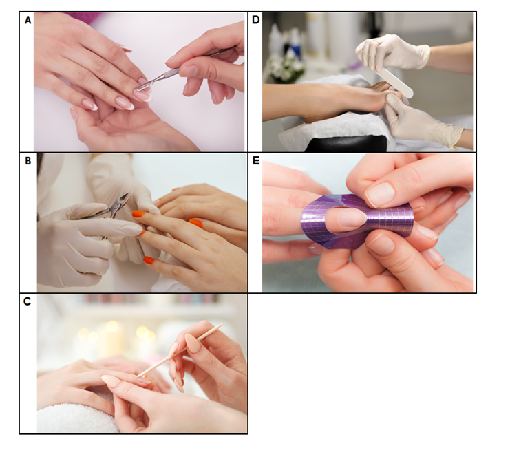

5. 아래 이미지에서 손가락이 들어가는 구멍을 선택하라.

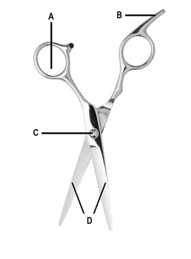

## NATIONAL-INTERSTATE COUNCIL OF STATE BOARDS OF COSMETOLOGY(NIC) 참조 문헌

이 목록은 NIC National Cosmetology 시험에서 다루는 내용을 개발하고 지원하는 데 사용되는 참조 문헌을 제공합니다. 각 시험 유형을 통틀어 똑같은 참조 문헌이 사용될 예정입니다. 시험 자료를 만드는 데 참조 문헌의 최신 버전이 사용되었으므로 응시자는 해당 버전을 사용해야 합니다.

### Standard

*Milady Standard Cosmetology and Foundations*

Copyrighted 2023

14th Edition

9780357871492

Milady www.Milady.com

Info@Milady.com;

*Pivot Point Fundamentals: Cosmetology, (101C – 113C)*

Copyrighted ©2023 Pivot Point International, Inc.

2nd Edition, 1st Printing, December 2023

978-1-957642-57-4 (Coursebook set)

Pivot Point International, Inc. www.pivot-point.com/shop/

info@pivot-point.com; 847-866-0500, Ext. 7368

### Supplemental

*Pivot Point Fundamentals: Cosmetology, (101 – 113)*

Copyrighted ©2016 Pivot Point International, Inc.

1st Edition, 1st Printing, November 2016

978–1-940593-56-2

Pivot Point International, Inc. www.pivot-point.com/shop/

info@pivot-point.com; 847-866-0500, Ext. 7368

*Milady Standard Cosmetology*

Copyrighted 2016

13th Edition

9781285769417

Milady www.Milady.com

Info@Milady.com;

*Salon Fundamentals Cosmetology*

Copyrighted 2014

3rd Edition

Pivot Point International, Inc. www.pivot-point.com

info@pivot-point.com; 847-866-0500, Ext. 7368

저작권 2022 National-Interstate Council of State Boards of Cosmetology, Inc.